# NEX1

Kajetán Poliak, Adam Novotný

18 øíjna 2019

# NEX - první domácí úkol

## 1. èást

- Namerte data: experiment nastavte tak, aby byl znahodneny !!!!! Poradi mereni si poznamenejte pro dalsi kontrolu pripadne zavislosti na poradi mereni. Jednotlive lidi ve skupine berte jako ruzne operatory experimentu (blokujte). Pocet replikaci u jednoho cloveka a jednoho casu vemte 1. V protokolu krom popisu experimentu diskutujte i jen promenne, ktere mohli mit na mereni vliv.

Experimetu se úèastnili dva operátoøi. Každý z operátorù se podrobil devíti mìøení (teèkování do 3 párù kruhù pomocí dominantní, nedominantní a obou rukou), kde každé meøení trvalo 10s. Poøadí meøení bylo znáhodnìno pomocí generátoru náhodné posloupnosti z www.random.org. Jako první se vygenerovala náhodné posloupnost celých èísel od 1 do 9, která urèovala poøadí meøení. Následnì se pomocí náhodné posloupnosti od 1 do 3 pøiøadila jedna z úrovní promìnné ruka ke každému ze tøí papírù obsahujícímu tøi rùzné velikosti kruhu. Na meøení mohlo mít vliv jak rozpoložení operátora (rùzné polohy sedu pøi experimentu, psychický nátlak okolí,..), tak nepøesnosti meøení èasu nebo rùzné psací potøeby operátorù.

## 2. èást

- Spoctete zakladni statistiky (mean, median a sd pro jednotlive faktory - velikost, ruka, operator) Zobrazte namerena data (box plot, interaction plot, effects plot, …) a okomentujte je co z danych obrazku muzeme pred samotnou analyzou rici o vysledku?

```r
# ZÁKLADÍ STATISTIKY
characteristics
```

```
##             adam   kajetan dominant nondominant    joint     1 cm
## Min.    12.00000 13.000000 14.00000    13.00000 12.00000 12.00000
## 1st Qu. 14.00000 16.000000 18.25000    15.50000 18.25000 13.00000
## Median  32.00000 25.000000 31.50000    27.00000 28.00000 13.50000
## Mean    30.66667 24.777778 29.16667    27.16667 26.83333 13.66667
## 3rd Qu. 45.00000 31.000000 37.25000    32.50000 31.00000 14.00000
## Max.    50.00000 39.000000 45.00000    50.00000 46.00000 16.00000
## Sd.     14.83240  9.038498 12.79714    14.06295 12.18879  1.36626
##              3 cm      5 cm
## Min.    23.000000 31.000000
## 1st Qu. 26.500000 33.000000
## Median  31.000000 42.000000
## Mean    29.166667 40.333333
## 3rd Qu. 31.750000 45.750000
## Max.    33.000000 50.000000
## Sd.      4.119061  8.041559
```

Tabulka zobrazuje základní statistiky experimentu. Vidíme, že operátoøi mají podobná minima ale maximum Adama je o celých 11 vyšší. Stejnì tak je vyšší støední hodnota poètu teèek Adama. Maxima u promìnných dominant, nondominant a joint tedy souvisí s operátorem Adam. Podle oèekávání vidíme, že hodnoty maxim i minim jsou vyšší se zvìtšujícím se polomìrem kruhu. Smìrodatná odchylka u promìnných adam, kajetán, dominant, nondominant a joint dosahují pomìrnì vysokých hodnot, to je vysvìtlitlé tím, že poèet teèek nabýval pro každý kruh se radikálnì lišil. Nejnižší støední hodnotu z rùzných úrovní promìnné ruka má joint.

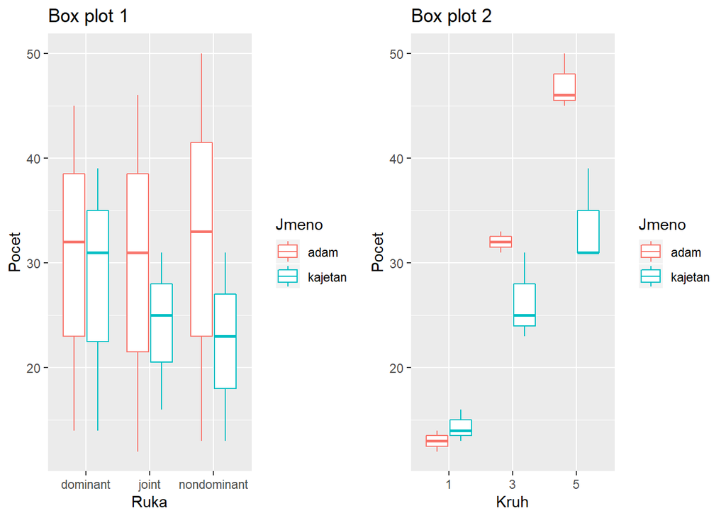

```r
#BOX-PLOTS
grid.arrange(p1,p2,ncol=2)
```

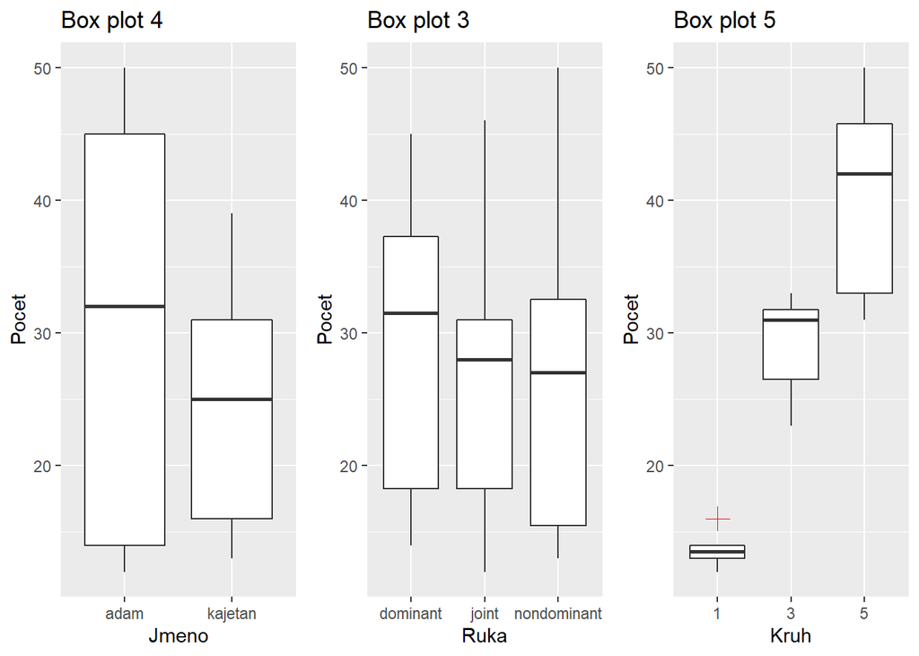

```r
grid.arrange(p4,p3,p5,ncol=3)
```

Z boxplotu 1 vidíme, že støední hodnoty u dominant mají operátoøi podobné. U nondominant a joint má Adam vyšší støední hodnoty i znatelnì vìtší variance. Boxplot 2 ukazuje, že Adam mìl vyšší poèet teèek všude, kromì nejmenšího kruhu.

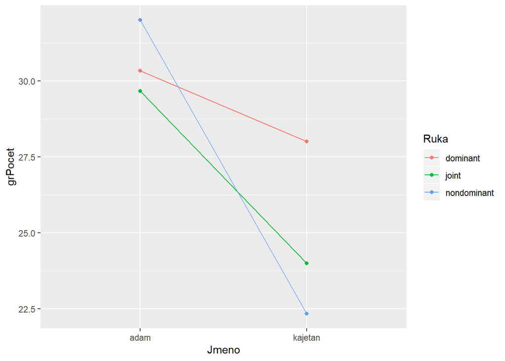

```r
#INTERACTION PLOTS
dat2 %>%
  ggplot() +
  aes(x = Jmeno, y = grPocet, color = Ruka) +
  geom_line(aes(group = Ruka)) +
  geom_point()
```

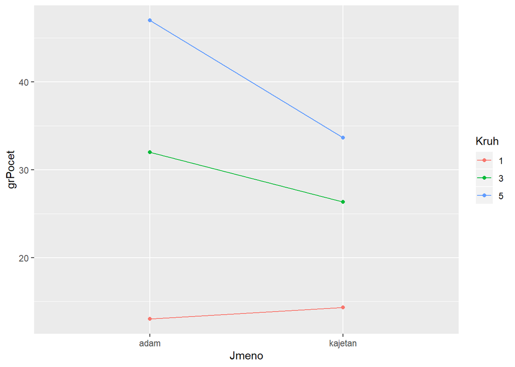

```r
dat3 %>%
  ggplot() +
  aes(x = Jmeno, y = grPocet, color = Kruh) +
  geom_line(aes(group = Kruh)) +
  geom_point()
```

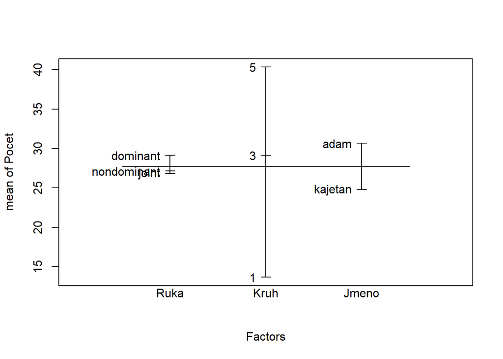

```r
#EFFECT PLOTS
plot.design(Pocet~Ruka+Kruh+Jmeno, data = dat)
```

## 3. èást

- Zamerte se zvlaste na faktory ruka a velikost kola. Otestujte hypotezu o schodnosti rozptylu pro jednotlive urovne a vhodnym testem overte stejnost strednich hodnot. Provedte Tukey HSD a Fisher LSD test pro parove porovnani stednich hodnot jednotlivych skupin s vybranou korekci p-hodnoty.

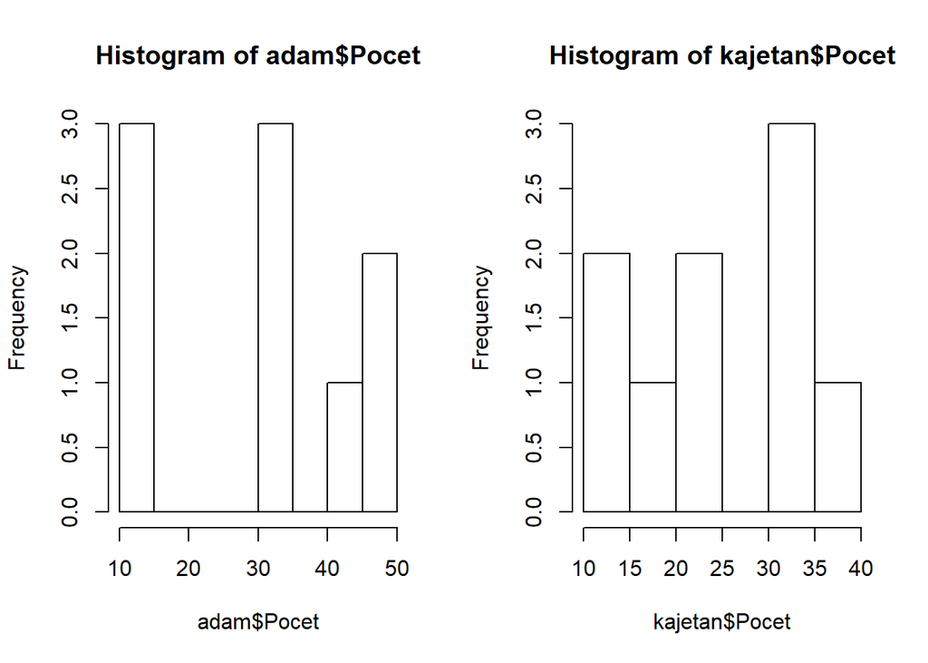

```r
#hypoteza shodnosti rozptylu pro jednotlive urovne
alpha = 0.95

# podminky f-testu: normalita, tj. histogram a shapiro-wilk test
par(mfrow = c(1,2))
hist(adam$Pocet, breaks=6)
hist(kajetan$Pocet, breaks=6)
```

```r
shapiro.test(adam$Pocet)
```

```
##
##  Shapiro-Wilk normality test
##
## data:  adam$Pocet
## W = 0.88219, p-value = 0.1656
```

```r
shapiro.test(kajetan$Pocet) # p-hodnoty > 0.05, tj. nezamitame normalitu
```

```
##
##  Shapiro-Wilk normality test
##
## data:  kajetan$Pocet
## W = 0.92229, p-value = 0.4116
```

```r
var.test(adam$Pocet, kajetan$Pocet, ratio = 1, alternative = "two.sided", conf.level = alpha) # p-hodnota > 0.05, tj. nezamitame rovnost rozptylu
```

```
##
##  F test to compare two variances
##
## data:  adam$Pocet and kajetan$Pocet
## F = 2.693, num df = 8, denom df = 8, p-value = 0.1827
## alternative hypothesis: true ratio of variances is not equal to 1
## 95 percent confidence interval:
##   0.607445 11.938599
## sample estimates:
## ratio of variances
##           2.692962
```

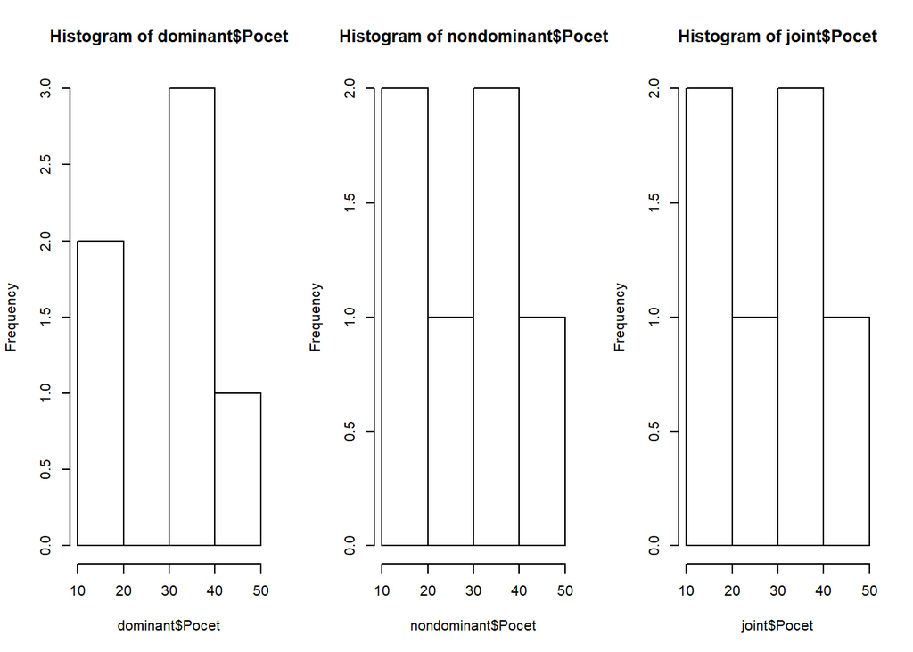

```r
## RUKA
par(mfrow = c(1,3))
hist(dominant$Pocet)
hist(nondominant$Pocet)
hist(joint$Pocet)
```

```r
shapiro.test(dominant$Pocet)
```

```
##
##  Shapiro-Wilk normality test
##
## data:  dominant$Pocet
## W = 0.89281, p-value = 0.3332
```

```r
shapiro.test(nondominant$Pocet)
```

```
##
##  Shapiro-Wilk normality test
##
## data:  nondominant$Pocet
## W = 0.91686, p-value = 0.4831
```

```r
shapiro.test(joint$Pocet) # p-hodnoty > 0.05, tj. nezamitame normalitu
```

```
##
##  Shapiro-Wilk normality test
##
## data:  joint$Pocet
## W = 0.9526, p-value = 0.7613
```

```r
var.test(dominant$Pocet, nondominant$Pocet, ratio = 1, alternative = "two.sided", conf.level = alpha) # p-hodnota > 0.05, tj. nezamitame rovnost rozptylu
```

```
##
##  F test to compare two variances
##
## data:  dominant$Pocet and nondominant$Pocet
## F = 0.82808, num df = 5, denom df = 5, p-value = 0.8411
## alternative hypothesis: true ratio of variances is not equal to 1
## 95 percent confidence interval:
##  0.1158741 5.9177775
## sample estimates:
## ratio of variances
##          0.8280802
```

```r
var.test(dominant$Pocet, joint$Pocet, ratio = 1, alternative = "two.sided", conf.level = alpha) # p-hodnota > 0.05, tj. nezamitame rovnost rozptylu
```

```
##
##  F test to compare two variances
##
## data:  dominant$Pocet and joint$Pocet
## F = 1.1023, num df = 5, denom df = 5, p-value = 0.9175
## alternative hypothesis: true ratio of variances is not equal to 1
## 95 percent confidence interval:
##  0.1542474 7.8775351
## sample estimates:
## ratio of variances
##           1.102311
```

```r
var.test(nondominant$Pocet, joint$Pocet, ratio = 1, alternative = "two.sided", conf.level = alpha) # p-hodnota > 0.05, tj. nezamitame rovnost rozptylu
```

```
##
##  F test to compare two variances
##
## data:  nondominant$Pocet and joint$Pocet
## F = 1.3312, num df = 5, denom df = 5, p-value = 0.7613
## alternative hypothesis: true ratio of variances is not equal to 1
## 95 percent confidence interval:
##  0.1862711 9.5130095
## sample estimates:
## ratio of variances
##           1.331164
```

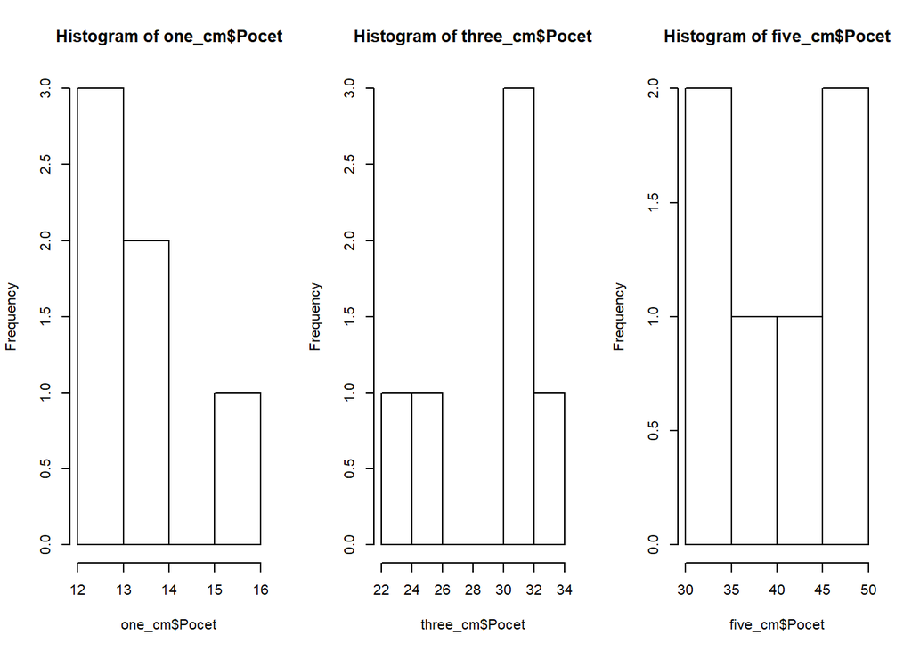

```r
## KRUH
par(mfrow = c(1,3))
hist(one_cm$Pocet)
hist(three_cm$Pocet)
hist(five_cm$Pocet)
```

```r
shapiro.test(one_cm$Pocet)
```

```
##
##  Shapiro-Wilk normality test
##
## data:  one_cm$Pocet
## W = 0.92664, p-value = 0.5544
```

```r
shapiro.test(three_cm$Pocet)
```

```
##
##  Shapiro-Wilk normality test
##
## data:  three_cm$Pocet
## W = 0.8307, p-value = 0.109
```

```r
shapiro.test(five_cm$Pocet) # p-hodnoty > 0.05, tj. nezamitame normalitu
```

```
##
##  Shapiro-Wilk normality test
##
## data:  five_cm$Pocet
## W = 0.88926, p-value = 0.3143
```

```r
var.test(one_cm$Pocet, three_cm$Pocet, ratio = 1, alternative = "two.sided", conf.level = alpha) # ZAMITAME!!!
```

```
##
##  F test to compare two variances
##
## data:  one_cm$Pocet and three_cm$Pocet
## F = 0.11002, num df = 5, denom df = 5, p-value = 0.0301
## alternative hypothesis: true ratio of variances is not equal to 1
## 95 percent confidence interval:
##  0.01539515 0.78624240
## sample estimates:
## ratio of variances
##          0.1100196
```

```r
var.test(one_cm$Pocet, five_cm$Pocet, ratio = 1, alternative = "two.sided", conf.level = alpha) # ZAMITAME!!!
```

```
##
##  F test to compare two variances
##
## data:  one_cm$Pocet and five_cm$Pocet
## F = 0.028866, num df = 5, denom df = 5, p-value = 0.00139
## alternative hypothesis: true ratio of variances is not equal to 1
## 95 percent confidence interval:
##  0.004039244 0.206287311
## sample estimates:
## ratio of variances
##         0.02886598
```

```r
var.test(three_cm$Pocet, five_cm$Pocet, ratio = 1, alternative = "two.sided", conf.level = alpha)
```

```
##
##  F test to compare two variances
##
## data:  three_cm$Pocet and five_cm$Pocet
## F = 0.26237, num df = 5, denom df = 5, p-value = 0.1683
## alternative hypothesis: true ratio of variances is not equal to 1
## 95 percent confidence interval:
##  0.03671384 1.87500430
## sample estimates:
## ratio of variances
##          0.2623711
```

Na zaèátku otestujeme normalitu jakožto podmínku F-testu. Pracujeme na 5% hladinì významnosti. Normalitu testujeme pomocí Shapirova-Wilkova testu. Pro operátory nezamítáme nulovou hypotézu o normálním rozdìlení. F-test pro operátory vrací p-hodnotu 0.1827, nezamítáme tedy nulovou hypotézu o rovnosti rozptylù. Pøecházíme k faktoru Ruka. Pro všechny úrovnì nezamítáme, dle Shapiro-wilkova testu, normalitu. F- test vrací pro páry dominant-nondominant, dominant-joint a nondominant-joint respektive p-hodnoty 0.84, 0.92 a 0.76 nezamítáme tedy rovnosti rozptylù. Jako poslední testujeme faktor Kruh. P-hodnoty S-W testu pro úrovnì 1cm, 3cm a 5cm jsou postupnì 0.55, 0.11 a 0.31, ani pro jednu z úrovní nezamítáme normalitu. F-test vrací pro dvojice 1cm-3cm, 1cm-5cm a 3cm-5cm p-hodnoty 0.030, 0.001 a 0.168 respektive. Pro dvojice 1cm-3cm a 1cm-5cm zamítáme nulovou hypotézu o rovnosti rozptylù.

```r
# hypoteza shodnosti strednich hodnot

pairwise.t.test(dat$Pocet,dat$Ruka,p.adjust.method="bonferroni", var.equal = T)
```

```
##
##  Pairwise comparisons using t tests with pooled SD
##
## data:  dat$Pocet and dat$Ruka
##
##             dominant joint
## joint       1        -
## nondominant 1        1
##
## P value adjustment method: bonferroni
```

```r
pairwise.t.test(dat$Pocet,dat$Ruka,p.adjust.method="hochberg", var.equal = T)
```

```
##
##  Pairwise comparisons using t tests with pooled SD
##
## data:  dat$Pocet and dat$Ruka
##
##             dominant joint
## joint       0.97     -
## nondominant 0.97     0.97
##
## P value adjustment method: hochberg
```

```r
pairwise.t.test(dat$Pocet,dat$Kruh,p.adjust.method="bonferroni", var.equal = F)
```

```
##
##  Pairwise comparisons using t tests with pooled SD
##
## data:  dat$Pocet and dat$Kruh
##
##   1       3
## 3 0.0004  -
## 5 8.4e-07 0.0069
##
## P value adjustment method: bonferroni
```

```r
pairwise.t.test(dat$Pocet,dat$Kruh,p.adjust.method="hochberg", var.equal = F)
```

```
##
##  Pairwise comparisons using t tests with pooled SD
##
## data:  dat$Pocet and dat$Kruh
##
##   1       3
## 3 0.00027 -
## 5 8.4e-07 0.00229
##
## P value adjustment method: hochberg
```

```r
#Tukey HSD + Fisher LSD
#Celkovy aov
#Kruh bychom ani testovat, protoze jsou ruzne variance ve skupinach 1cm, 3cm, 5cm
aov_celk =  aov(Pocet ~ Jmeno + Ruka + Kruh, data = dat) #ruka neni stat. vyznamna
summary(aov_celk)
```

```
##             Df Sum Sq Mean Sq F value   Pr(>F)
## Jmeno        1  156.1   156.1   7.728   0.0167 *
## Ruka         2   19.1     9.6   0.473   0.6342
## Kruh         2 2152.1  1076.1  53.285 1.07e-06 ***
## Residuals   12  242.3    20.2
## ---
## Signif. codes:  0 '***' 0.001 '**' 0.01 '*' 0.05 '.' 0.1 ' ' 1
```

```r
LSD1 <- LSD.test(aov_celk, "Jmeno"); LSD1
```

```
## $statistics
##    MSerror Df     Mean       CV  t.value      LSD
##   20.19444 12 27.72222 16.21018 2.178813 4.615615
##
## $parameters
##         test p.ajusted name.t ntr alpha
##   Fisher-LSD      none  Jmeno   2  0.05
##
## $means
##            Pocet       std r      LCL      UCL Min Max Q25 Q50 Q75
## adam    30.66667 14.832397 9 27.40293 33.93040  12  50  14  32  45
## kajetan 24.77778  9.038498 9 21.51404 28.04151  13  39  16  25  31
##
## $comparison
## NULL
##
## $groups
##            Pocet groups
## adam    30.66667      a
## kajetan 24.77778      b
##
## attr(,"class")
## [1] "group"
```

```r
LSD2 <- LSD.test(aov_celk, "Ruka"); LSD2
```

```
## $statistics
##    MSerror Df     Mean       CV  t.value      LSD
##   20.19444 12 27.72222 16.21018 2.178813 5.652951
##
## $parameters
##         test p.ajusted name.t ntr alpha
##   Fisher-LSD      none   Ruka   3  0.05
##
## $means
##                Pocet      std r      LCL      UCL Min Max   Q25  Q50   Q75
## dominant    29.16667 12.79714 6 25.16943 33.16391  14  45 18.25 31.5 37.25
## joint       26.83333 12.18879 6 22.83609 30.83057  12  46 18.25 28.0 31.00
## nondominant 27.16667 14.06295 6 23.16943 31.16391  13  50 15.50 27.0 32.50
##
## $comparison
## NULL
##
## $groups
##                Pocet groups
## dominant    29.16667      a
## nondominant 27.16667      a
## joint       26.83333      a
##
## attr(,"class")
## [1] "group"
```

```r
LSD3 <- LSD.test(aov_celk, "Kruh"); LSD3
```

```
## $statistics
##    MSerror Df     Mean       CV  t.value      LSD
##   20.19444 12 27.72222 16.21018 2.178813 5.652951
##
## $parameters
##         test p.ajusted name.t ntr alpha
##   Fisher-LSD      none   Kruh   3  0.05
##
## $means
##      Pocet      std r       LCL      UCL Min Max  Q25  Q50   Q75
## 1 13.66667 1.366260 6  9.669426 17.66391  12  16 13.0 13.5 14.00
## 3 29.16667 4.119061 6 25.169426 33.16391  23  33 26.5 31.0 31.75
## 5 40.33333 8.041559 6 36.336093 44.33057  31  50 33.0 42.0 45.75
##
## $comparison
## NULL
##
## $groups
##      Pocet groups
## 5 40.33333      a
## 3 29.16667      b
## 1 13.66667      c
##
## attr(,"class")
## [1] "group"
```

```r
TukeyHSD(aov_celk, "Jmeno", ordered = FALSE, conf.level = alpha)
```

```
##   Tukey multiple comparisons of means
##     95% family-wise confidence level
##
## Fit: aov(formula = Pocet ~ Jmeno + Ruka + Kruh, data = dat)
##
## $Jmeno
##                   diff      lwr       upr     p adj
## kajetan-adam -5.888889 -10.5045 -1.273273 0.0166546
```

```r
TukeyHSD(aov_celk, "Ruka", ordered = FALSE, conf.level = alpha)
```

```
##   Tukey multiple comparisons of means
##     95% family-wise confidence level
##
## Fit: aov(formula = Pocet ~ Jmeno + Ruka + Kruh, data = dat)
##
## $Ruka
##                            diff       lwr      upr     p adj
## joint-dominant       -2.3333333 -9.255132 4.588465 0.6509234
## nondominant-dominant -2.0000000 -8.921799 4.921799 0.7272003
## nondominant-joint     0.3333333 -6.588465 7.255132 0.9909481
```

```r
TukeyHSD(aov_celk, "Kruh", ordered = FALSE, conf.level = alpha)
```

```
##   Tukey multiple comparisons of means
##     95% family-wise confidence level
##
## Fit: aov(formula = Pocet ~ Jmeno + Ruka + Kruh, data = dat)
##
## $Kruh
##         diff       lwr      upr     p adj
## 3-1 15.50000  8.578201 22.42180 0.0001769
## 5-1 26.66667 19.744868 33.58847 0.0000007
## 5-3 11.16667  4.244868 18.08847 0.0027206
```

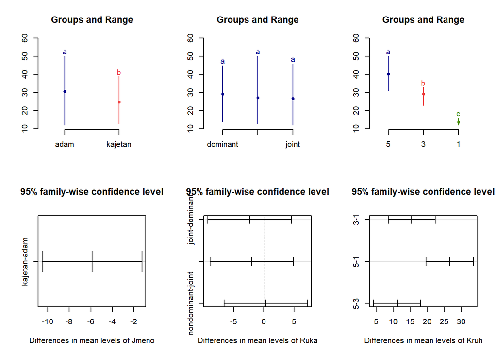

```r
par(mfrow = c(2,3))
plot(LSD1)
plot(LSD2)
plot(LSD3)
plot(TukeyHSD(aov_celk, "Jmeno", ordered = FALSE,las=1))
plot(TukeyHSD(aov_celk, "Ruka", ordered = FALSE,las=1))
plot(TukeyHSD(aov_celk, "Kruh", ordered = FALSE,las=1))
```

## 4.èást

- Analyzute data pomoci ANOVA (vsechny promenne berte jako faktor) - s predpokladem, ze kazdy z ucastniku experimentu tvori jeden blok. - diskutujte vysledky, overte predpoklady, vykreslete QQ-plot, residua x fitted values, resida x cas, … - diskutujte vliv znahodneni experimentu a vyvoj rezidui v case (cislo mereni)

```r
summary(aov_celk)
```

```
##             Df Sum Sq Mean Sq F value   Pr(>F)
## Jmeno        1  156.1   156.1   7.728   0.0167 *
## Ruka         2   19.1     9.6   0.473   0.6342
## Kruh         2 2152.1  1076.1  53.285 1.07e-06 ***
## Residuals   12  242.3    20.2
## ---
## Signif. codes:  0 '***' 0.001 '**' 0.01 '*' 0.05 '.' 0.1 ' ' 1
```

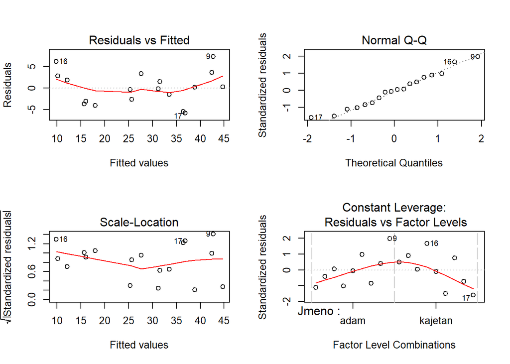

```r
par(mfrow = c(2,2))
plot(aov_celk)
```

ANOVA vrací pro faktory Jmeno a Kruh p-hodnoty < 0.05, tzn, mají vliv na promìnnou Poèe, faktor Ruka signifikantní není, proto jej vyhodíme z modelu. Residuals vs. Fitted plot ukazuje nìkolik možných outlierù, které ovlivòují lineární trend u obou koncù køivky. Bod è.17 je znaènì vychýlený i u Normálního Q-Q plotu, kde máme zcela zøetelný lineární trend. Scale-Location plot má body víceménì rovnomìrnì rozdìlené a køivka zaujímá horizontální polohu, vypadá to tedy na rovnomìrné rozdìlení reziduí pøes prediktory a homoskedasticitu.

## 5.èást

- Porovnejte a diskutujte vysledky z bodu 3 a 4.

## 6. èást

- Pokud data nesplnuji predpoklady pro pouziti ANOVA, diskutujte mozne transformace (logaritmicka, Box-Cox, …) a duvod proc data predpoklady nesplnuji? Vyskyt outlieru, zpusob mereni, divny operator, …

```r
#log trafo
aov1 <- aov(Pocet ~ Jmeno + Ruka + Kruh, data = dat); summary(aov1)
```

```
##             Df Sum Sq Mean Sq F value   Pr(>F)
## Jmeno        1  156.1   156.1   7.728   0.0167 *
## Ruka         2   19.1     9.6   0.473   0.6342
## Kruh         2 2152.1  1076.1  53.285 1.07e-06 ***
## Residuals   12  242.3    20.2
## ---
## Signif. codes:  0 '***' 0.001 '**' 0.01 '*' 0.05 '.' 0.1 ' ' 1
```

```r
aov2 <- aov(Pocet ~ Jmeno  + Kruh  + Jmeno*Kruh, data = dat)
aov_trafo <-  aov(log(Pocet) ~ Jmeno  + Kruh  + Jmeno*Kruh, data = dat) #ruka neni stat. vyznamna
summary(aov_trafo)
```

```
##             Df Sum Sq Mean Sq F value   Pr(>F)
## Jmeno        1  0.099  0.0992   9.539  0.00939 **
## Kruh         2  3.619  1.8095 174.068 1.37e-09 ***
## Jmeno:Kruh   2  0.148  0.0741   7.128  0.00911 **
## Residuals   12  0.125  0.0104
## ---
## Signif. codes:  0 '***' 0.001 '**' 0.01 '*' 0.05 '.' 0.1 ' ' 1
```

```r
shapiro.test(aov_trafo$residuals)
```

```
##
##  Shapiro-Wilk normality test
##
## data:  aov_trafo$residuals
## W = 0.94021, p-value = 0.2922
```

```r
require(lmtest)
bptest(aov_trafo)
```

```
##
##  studentized Breusch-Pagan test
##
## data:  aov_trafo
## BP = 7.7308, df = 5, p-value = 0.1717
```

```r
#B-C trafo
require(EnvStats)
modelBC <- boxcox(aov_celk, objective.name = "PPCC", lambda = seq(0,5, by=0.5)); modelBC
```

```
##
## Results of Box-Cox Transformation
## ---------------------------------
##
## Objective Name:                  PPCC
##
## Linear Model:                    aov_celk
##
## Sample Size:                     18
##
##  lambda      PPCC
##     0.0 0.9851693
##     0.5 0.9813793
##     1.0 0.9909187
##     1.5 0.9942694
##     2.0 0.9945821
##     2.5 0.9916795
##     3.0 0.9877888
##     3.5 0.9829078
##     4.0 0.9779361
##     4.5 0.9722093
##     5.0 0.9674904
```

```r
 lambda <- cbind(modelBC$lambda,modelBC$objective)
 lam <- lambda[which.max(lambda[,2]),1];lam
```

```
## [1] 2
```

```r
 modelBC_final <- aov((Pocet)^lam ~ Jmeno + Kruh + Jmeno*Kruh , data = dat);
 summary(modelBC_final)
```

```
##             Df  Sum Sq Mean Sq F value   Pr(>F)
## Jmeno        1  909001  909001   24.10  0.00036 ***
## Kruh         2 6700590 3350295   88.83 6.42e-08 ***
## Jmeno:Kruh   2  950903  475452   12.61  0.00112 **
## Residuals   12  452611   37718
## ---
## Signif. codes:  0 '***' 0.001 '**' 0.01 '*' 0.05 '.' 0.1 ' ' 1
```

## 7. èást

- Vyberte nejvhodnejsi model a i kdyby nesplnoval predpoklady pro pouziti ANOVA reste nasledujici:
  - Spoctete silu testu v ANOVA (pro max. dvoufaktorovou analyzu - jeden z faktoru zanedbejte, nebo vezmete mereni pro jednu jeho konkretni uroven)
  - Predpokladejme, ze standartni odchylka disturbanci bude pro provadeny experiment 4 a maximalni (pro nas signifikantni) rozdil, ktery chceme detekovat je 5 bodu v kruhu. Spoctete pocet potrebnych replikaci, aby sila vysledneho testu byla vetsi nez 0.9

```r
# vybirame asi Pocet ~  Jmeno*Kruh
anova_fin <- aov(Pocet ~ Jmeno*Kruh, data = dat)
summary(anova_fin)
```

```
##             Df Sum Sq Mean Sq F value   Pr(>F)
## Jmeno        1  156.1   156.1  18.727 0.000983 ***
## Kruh         2 2152.1  1076.1 129.127 7.66e-09 ***
## Jmeno:Kruh   2  161.4    80.7   9.687 0.003131 **
## Residuals   12  100.0     8.3
## ---
## Signif. codes:  0 '***' 0.001 '**' 0.01 '*' 0.05 '.' 0.1 ' ' 1
```

```r
shapiro.test(anova_fin$residuals) # OK...zamitame
```

```
##
##  Shapiro-Wilk normality test
##
## data:  anova_fin$residuals
## W = 0.92219, p-value = 0.1413
```

```r
#leveneTest(anova_fin) #OK....zamitame
var1 <- var(dat$Pocet[which(dat$Jmeno=="kajetan")])
var2 <- var(dat$Pocet[which(dat$Jmeno=="adam")])
mean1 <- mean(dat$Pocet[which(dat$Jmeno=="kajetan")])
mean2 <- mean(dat$Pocet[which(dat$Jmeno=="adam")])

variances <- c(var1,var2)
means <- c(mean1, mean2)

power.anova.test(groups = 2, between.var = var(means), n = length(dat$Pocet[which(dat$Jmeno=="kajetan")]) , sig.level = 0.05, within.var = 16)
```

```
##
##      Balanced one-way analysis of variance power calculation
##
##          groups = 2
##               n = 9
##     between.var = 17.33951
##      within.var = 16
##       sig.level = 0.05
##           power = 0.8342625
##
## NOTE: n is number in each group
```

```r
# kolik potrebnych replikaci pro power > 0,9
power.anova.test(groups = 2, between.var = var(means), n = NULL , sig.level = 0.05, within.var = 16, power = 0.9) #alespon 11 replikaci
```

```
##
##      Balanced one-way analysis of variance power calculation
##
##          groups = 2
##               n = 10.75368
##     between.var = 17.33951
##      within.var = 16
##       sig.level = 0.05
##           power = 0.9
##
## NOTE: n is number in each group
```

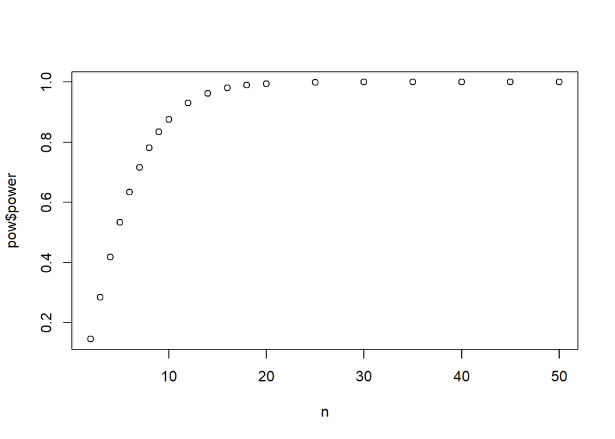

```r
n <- c(seq(2,10,by=1),seq(12,20,by=2),seq(25,50,by=5))
pow <- power.anova.test(groups = 2, between.var = var(means), n = n , sig.level = 0.05, within.var = 16)
plot(n, pow$power)
```

## 8. èást

- Vytvorte regresni model, kde nebudete uvazovat bloky a velikost kruhu bude kvantitativni promenna. - zkuste pridat do modelu i druhou mocninu a porovnejte dva regresni modely mezi s sebou a vyberte vhodnejsi - overte predpoklady pro pouziti vybraneho modelu a vykreslete QQ-plot, residua x fitted values, resida x prumer , …